# Red Inmobiliaria de Cali

Ejercicio Notaría 2 — Introducción a la Complejidad 2026-I — Universidad del Valle

Daniel Otero

2026

# 1 Paquetes

```r
library(igraph)
library(dplyr)
library(stringr)
```

# 2 Carga y Exploración Inicial

## 2.1 Leer el archivo

```r
# Leer el CSV con encoding UTF-8
datos_raw <- read.csv("Base de datos notaria 2.csv",
                      fileEncoding = "UTF-8",
                      stringsAsFactors = FALSE)

cat("Dimensiones:", nrow(datos_raw), "filas ×", ncol(datos_raw), "columnas\n")
```

```
## Dimensiones: 259 filas × 5 columnas
```

```r
cat("Columnas:", paste(names(datos_raw), collapse = ", "), "\n")
```

```
## Columnas: vendedor, comprador, Valor, Negocio, fecha
```

## 2.2 Primera mirada

```r
# Ver las primeras filas
head(datos_raw, 10)
```

|  | vendedor | comprador | Valor | Negocio | fecha |
| --- | --- | --- | --- | --- | --- |
| 1 | ana borrero | ignacio sinisterra | 700,00 | hipoteca sobre lote de terrenos en la charmea 1% | 1938 |
| 2 | ana borrero | mercedes villegas | 450,00 | vende 300 m2 de terreno en la chamea | 1938 |
| 3 | ana borrero | emilia mejia de borrero fragoni | 300,00 | vende 150 m2 de terreno en la chamea | 1938 |
| 4 | N/A | ana maria martinez velez | 700,00 | vende 722 m2 de terreno en la chamea | 1938 |
| 5 | aida micaela velasco garcia | gero velasco garcia | 1.600,00 | vende derecho sobre casa en Cali cra. 3a calles 14-15 | 1938 |
| 6 | susana vinasco de quintana | rashid eff muhnmaa | 1.500,00 | vende casa en cali calle 5 carrera 4a area 5.33 x 34-66 | 1938 |
| 7 | emilia mejia de borrero fragoni | dominga guiterrez de jeager | 461,00 | cancelacion de saldo de compraventa | 1938 |
| 8 | banco agrario hipotecario | joaquina hurtado de piedrahita | 4.000,00 | cancelacion de saldo de compraventa | 1938 |
| 9 | marco a tejada | georgina jaramillo de sarria | 1.000,00 | vende casa en cali calle 23 carrera 1a y 5a area 12-17x57-10 | 1938 |
| 10 | francisco de paula barona | agustin velasco b | 500,00 | vende mejoras ubicadas en candelaria | 1938 |

```r
# Distribución de registros por año
table(datos_raw$fecha)
```

```
##
## 1938 1939 1940 1941 1943
##   41   72   62   18   66
```

Ya vemos los problemas principales de calidad de datos que hay que resolver antes de construir la red:

- **Espacios extra** en nombres (`"ana borrero "`, `"mercedes villegas "`)
- **Mayúsculas inconsistentes**: 1938 en minúsculas, 1939 en Title Case, 1940 de nuevo en minúsculas
- **Valores `N/A` y `NA`** en vendedor o comprador
- **Formato del valor monetario inconsistente**: `"700,00"` (coma como decimal), `"3050$"` (dólar al final)
- **Campos vacíos** en comprador (fila de Lizcano Hermanos)

# 3 Limpieza de Datos

## 3.1 Limpiar nombres de actores

```r
limpiar_nombre <- function(x) {
  x %>%
    str_trim() %>%                        # eliminar espacios al inicio y al final
    str_squish() %>%                      # colapsar espacios internos múltiples
    str_to_title() %>%                    # Title Case uniforme
    str_replace_all("\\bDe\\b", "de") %>% # "de" en minúsculas (preposición)
    str_replace_all("\\bDel\\b", "del") %>%
    str_replace_all("\\bY\\b", "y") %>%
    str_replace_all("\\bV\\b", "v") %>%
    str_replace_all("\\bS\\.A\\b", "S.A") %>%
    na_if("N/A") %>%                      # convertir "N/A" texto a NA real
    na_if("NA") %>%
    na_if("")
}

datos_raw$vendedor  <- limpiar_nombre(datos_raw$vendedor)
datos_raw$comprador <- limpiar_nombre(datos_raw$comprador)
```

## 3.2 Limpiar valores monetarios

```r
limpiar_valor <- function(x) {
  x %>%
    str_replace_all("\\$", "") %>%   # eliminar símbolo $
    str_replace_all("\\.", "") %>%   # eliminar puntos de miles
    str_replace_all(",", ".") %>%    # coma decimal → punto decimal
    str_trim() %>%
    as.numeric()
}

datos_raw$Valor <- limpiar_valor(datos_raw$Valor)

cat("Rango de valores (en pesos):\n")
```

```
## Rango de valores (en pesos):
```

```r
cat("  Mínimo :", min(datos_raw$Valor, na.rm = TRUE), "\n")
```

```
##   Mínimo : 80
```

```r
cat("  Mediana:", median(datos_raw$Valor, na.rm = TRUE), "\n")
```

```
##   Mediana: 1700
```

```r
cat("  Máximo :", max(datos_raw$Valor, na.rm = TRUE), "\n")
```

```
##   Máximo : 731041
```

```r
cat("  Con NA :", sum(is.na(datos_raw$Valor)), "registros\n")
```

```
##   Con NA : 3 registros
```

## 3.3 Filtrar registros incompletos

Para construir la red necesitamos que **ambos** extremos del vínculo (vendedor y comprador) estén presentes.

```r
datos_raw$fecha <- as.integer(datos_raw$fecha)

datos <- datos_raw %>%
  filter(!is.na(vendedor), !is.na(comprador)) %>%  # eliminar N/A en actores
  filter(vendedor != comprador)                     # eliminar auto-transacciones

cat("Registros originales :", nrow(datos_raw), "\n")
```

```
## Registros originales : 259
```

```r
cat("Registros usables    :", nrow(datos),     "\n")
```

```
## Registros usables    : 257
```

```r
cat("Registros eliminados :", nrow(datos_raw) - nrow(datos), "\n")
```

```
## Registros eliminados : 2
```

## 3.4 Tabla de datos limpios

```r
head(datos, 15)
```

|  | vendedor | comprador | Valor | Negocio | fecha |
| --- | --- | --- | --- | --- | --- |
| 1 | Ana Borrero | Ignacio Sinisterra | 700 | hipoteca sobre lote de terrenos en la charmea 1% | 1938 |
| 2 | Ana Borrero | Mercedes Villegas | 450 | vende 300 m2 de terreno en la chamea | 1938 |
| 3 | Ana Borrero | Emilia Mejia de Borrero Fragoni | 300 | vende 150 m2 de terreno en la chamea | 1938 |
| 4 | Aida Micaela Velasco Garcia | Gero Velasco Garcia | 1600 | vende derecho sobre casa en Cali cra. 3a calles 14-15 | 1938 |
| 5 | Susana Vinasco de Quintana | Rashid Eff Muhnmaa | 1500 | vende casa en cali calle 5 carrera 4a area 5.33 x 34-66 | 1938 |
| 6 | Emilia Mejia de Borrero Fragoni | Dominga Guiterrez de Jeager | 461 | cancelacion de saldo de compraventa | 1938 |
| 7 | Banco Agrario Hipotecario | Joaquina Hurtado de Piedrahita | 4000 | cancelacion de saldo de compraventa | 1938 |
| 8 | Marco A Tejada | Georgina Jaramillo de Sarria | 1000 | vende casa en cali calle 23 carrera 1a y 5a area 12-17x57-10 | 1938 |
| 9 | Francisco de Paula Barona | Agustin Velasco B | 500 | vende mejoras ubicadas en candelaria | 1938 |
| 10 | Rafael Sinisterra | Julia Castro de Rojas | 3800 | vende casa en la avenida de belalcazar area 885 m2 | 1938 |

[output cut: 5 more lines]

# 4 Exploración de Actores

## 4.1 ¿Quiénes aparecen más veces?

Antes de construir la red, conviene saber quiénes son los actores más activos en el mercado inmobiliario.

```r
# Contar apariciones totales (como vendedor + como comprador)
vendedores  <- datos %>% count(vendedor,  name = "veces_vendedor")  %>% rename(actor = vendedor)
compradores <- datos %>% count(comprador, name = "veces_comprador") %>% rename(actor = comprador)

actividad <- full_join(vendedores, compradores, by = "actor") %>%
  replace(is.na(.), 0) %>%
  mutate(total = veces_vendedor + veces_comprador) %>%
  arrange(desc(total))

cat("Top 20 actores más activos:\n")
```

```
## Top 20 actores más activos:
```

```r
head(actividad, 20)
```

|  | actor | veces_vendedor | veces_comprador | total |
| --- | --- | --- | --- | --- |
| 1 | Sebastian Caicedo | 5 | 8 | 13 |
| 2 | Ana Borrero | 7 | 1 | 8 |
| 3 | Banco Central Hipotecario | 1 | 7 | 8 |
| 4 | Susana Caicedo | 6 | 0 | 6 |
| 5 | Sociedad Urbanizadora Colombiana | 5 | 0 | 5 |
| 6 | Banco de Colombia | 2 | 2 | 4 |
| 7 | Emilia Gasca v de Barney | 4 | 0 | 4 |
| 8 | Jose Ricci | 2 | 2 | 4 |
| 9 | Rosa Lowid de Arboleda | 4 | 0 | 4 |
| 10 | Banco Agrario Hipotecario | 2 | 1 | 3 |

[output cut: 10 more lines]

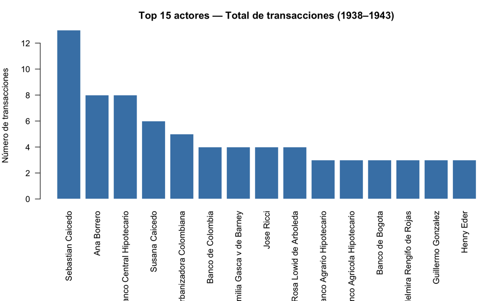

```r
top15 <- head(actividad, 15)

par(mar = c(10, 4, 3, 1))
barplot(
  top15$total,
  names.arg = top15$actor,
  las = 2,
  col = "steelblue",
  border = "white",
  main = "Top 15 actores — Total de transacciones (1938–1943)",
  ylab = "Número de transacciones"
)
```

## 4.2 Distribución de transacciones por año

```r
table(datos$fecha)
```

```
##
## 1938 1939 1940 1941 1943
##   39   72   62   18   66
```

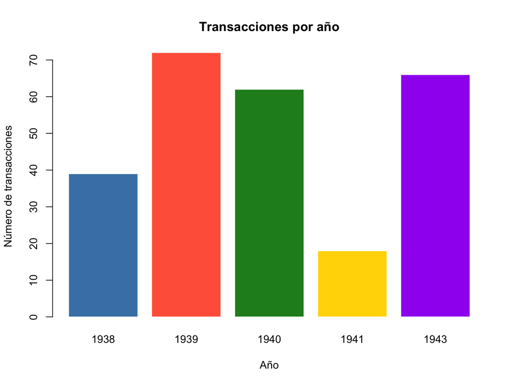

```r
conteo_año <- table(datos$fecha)
barplot(
  conteo_año,
  col = c("steelblue", "tomato", "forestgreen", "gold", "purple", "orange")[
    seq_along(conteo_año)
  ],
  border = "white",
  main = "Transacciones por año",
  xlab = "Año",
  ylab = "Número de transacciones"
)
```

# 5 Construcción de la Red

## 5.1 Crear el grafo dirigido y ponderado

Las transacciones inmobiliarias tienen **dirección**: el vendedor transfiere al comprador. Por eso construimos un **grafo dirigido** (`directed = TRUE`).

El **peso** de cada arista es el valor de la transacción en pesos. Cuando hay múltiples transacciones entre los mismos actores, las agregamos sumando los valores.

```r
# Crear la lista de aristas: una fila = una transacción
aristas <- datos %>%
  select(from = vendedor, to = comprador, peso = Valor, fecha) %>%
  filter(!is.na(peso))  # solo transacciones con valor conocido

# Crear el grafo dirigido desde el data frame
g <- graph_from_data_frame(aristas, directed = TRUE)

cat("=== Red Inmobiliaria de Cali (1938–1943) ===\n")
```

```
## === Red Inmobiliaria de Cali (1938–1943) ===
```

```r
cat("Nodos (actores)      :", vcount(g), "\n")
```

```
## Nodos (actores)      : 421
```

```r
cat("Aristas (transac.)   :", ecount(g), "\n")
```

```
## Aristas (transac.)   : 254
```

```r
cat("¿Es simple?          :", is_simple(g), "\n")
```

```
## ¿Es simple?          : FALSE
```

```r
cat("Aristas múltiples    :", sum(which_multiple(g)), "\n")
```

```
## Aristas múltiples    : 3
```

## 5.2 Simplificar: agregar transacciones múltiples

Cuando dos actores realizaron más de una transacción, las colapsamos en **una sola arista** cuyo peso es la **suma de los valores**.

```r
# Agregar transacciones múltiples entre mismos actores
aristas_agregadas <- aristas %>%
  group_by(from, to) %>%
  summarise(
    peso     = sum(peso, na.rm = TRUE),
    n_transac = n(),
    .groups  = "drop"
  )

# Reconstruir el grafo con aristas agregadas
g <- graph_from_data_frame(aristas_agregadas, directed = TRUE)

cat("=== Después de agregar transacciones múltiples ===\n")
```

```
## === Después de agregar transacciones múltiples ===
```

```r
cat("Nodos (actores)      :", vcount(g), "\n")
```

```
## Nodos (actores)      : 421
```

```r
cat("Aristas (vínculos)   :", ecount(g), "\n")
```

```
## Aristas (vínculos)   : 251
```

```r
cat("¿Es simple?          :", is_simple(g), "\n")
```

```
## ¿Es simple?          : TRUE
```

## 5.3 Estructura general

```r
# ¿La red es conexa como grafo no dirigido?
cat("¿Es débilmente conexa?", is_connected(g, mode = "weak"), "\n")
```

```
## ¿Es débilmente conexa? FALSE
```

```r
# Componentes débilmente conexas
comp <- components(g, mode = "weak")
cat("Número de componentes:", comp$no, "\n")
```

```
## Número de componentes: 171
```

```r
cat("Tamaño del componente gigante:", max(comp$csize), "nodos\n")
```

```
## Tamaño del componente gigante: 15 nodos
```

```r
# Densidad
cat("Densidad de la red:", round(edge_density(g), 4), "\n")
```

```
## Densidad de la red: 0.0014
```

```r
# Reciprocidad: ¿hay actores que compraron Y vendieron entre sí?
cat("Reciprocidad:", round(reciprocity(g), 3), "\n")
```

```
## Reciprocidad: 0.008
```

# 6 Visualización de la Red

## 6.1 Visualización completa

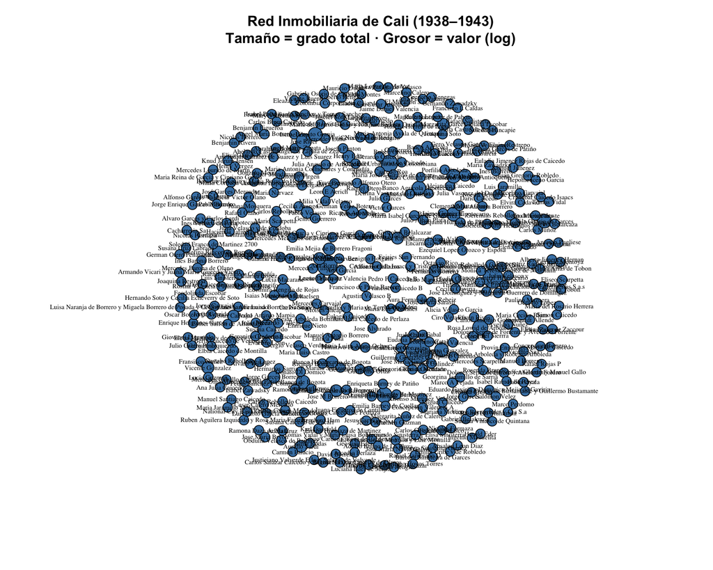

```r
set.seed(42)

# Tamaño de nodo proporcional al grado total (in + out)
grado_total <- degree(g, mode = "all")

# Escalar los pesos para el grosor de aristas
pesos_norm <- log1p(E(g)$peso) / max(log1p(E(g)$peso)) * 4 + 0.5

plot(g,
     layout          = layout_with_fr(g),
     vertex.size     = sqrt(grado_total) * 3 + 2,
     vertex.color    = "steelblue",
     vertex.label    = ifelse(grado_total >= quantile(grado_total, 0.85),
                              V(g)$name, NA),
     vertex.label.cex   = 0.55,
     vertex.label.color = "black",
     edge.width      = pesos_norm,
     edge.color      = adjustcolor("gray40", alpha.f = 0.6),
     edge.arrow.size = 0.25,
     main            = "Red Inmobiliaria de Cali (1938–1943)\nTamaño = grado total · Grosor = valor (log)"
)
```

## 6.2 Subred: solo el componente gigante

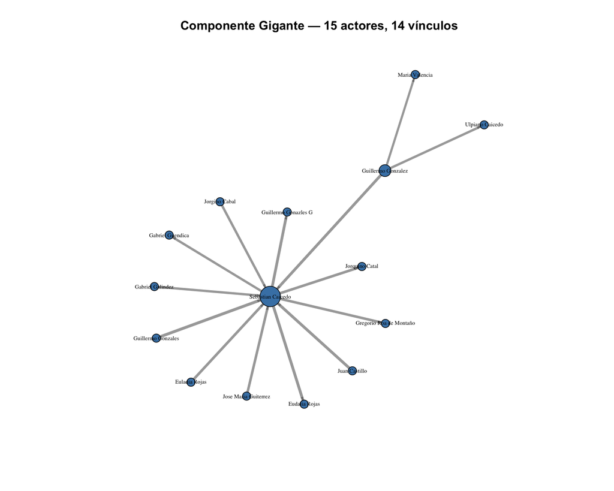

```r
# Extraer el componente gigante
nodos_gigante <- V(g)[comp$membership == which.max(comp$csize)]
g_gigante <- induced_subgraph(g, nodos_gigante)

set.seed(42)
grado_g <- degree(g_gigante, mode = "all")
pesos_g  <- log1p(E(g_gigante)$peso) / max(log1p(E(g_gigante)$peso)) * 4 + 0.5

plot(g_gigante,
     layout          = layout_with_fr(g_gigante),
     vertex.size     = sqrt(grado_g) * 3 + 2,
     vertex.color    = "steelblue",
     vertex.label    = ifelse(grado_g >= quantile(grado_g, 0.85),
                              V(g_gigante)$name, NA),
     vertex.label.cex   = 0.55,
     vertex.label.color = "black",
     edge.width      = pesos_g,
     edge.color      = adjustcolor("gray40", alpha.f = 0.6),
     edge.arrow.size = 0.25,
     main            = paste0("Componente Gigante — ",
                              vcount(g_gigante), " actores, ",
                              ecount(g_gigante), " vínculos")
)
```

# 7 Análisis de Centralidad

## 7.1 Grado de entrada y de salida

En una red de compraventas:

- **Grado de salida** (*out-degree*): número de veces que el actor **vendió** (a distintos compradores).
- **Grado de entrada** (*in-degree*): número de veces que el actor **compró** (a distintos vendedores).

```r
grado_out <- degree(g, mode = "out")
grado_in  <- degree(g, mode = "in")

tabla_grado <- data.frame(
  Actor        = V(g)$name,
  Vendió_a     = grado_out,
  Compró_a     = grado_in,
  Total        = grado_out + grado_in
) %>%
  arrange(desc(Total))

rownames(tabla_grado) <- NULL

cat("Top 20 actores por grado total:\n")
```

```
## Top 20 actores por grado total:
```

```r
head(tabla_grado, 20)
```

|  | Actor | Vendió_a | Compró_a | Total |
| --- | --- | --- | --- | --- |
| 1 | Sebastian Caicedo | 5 | 7 | 12 |
| 2 | Ana Borrero | 7 | 1 | 8 |
| 3 | Banco Central Hipotecario | 1 | 7 | 8 |
| 4 | Susana Caicedo | 6 | 0 | 6 |
| 5 | Sociedad Urbanizadora Colombiana | 5 | 0 | 5 |
| 6 | Emilia Gasca v de Barney | 4 | 0 | 4 |
| 7 | Jose Ricci | 2 | 2 | 4 |
| 8 | Rosa Lowid de Arboleda | 4 | 0 | 4 |
| 9 | Banco Agrario Hipotecario | 2 | 1 | 3 |
| 10 | Banco Agricola Hipotecario | 3 | 0 | 3 |

[output cut: 10 more lines]

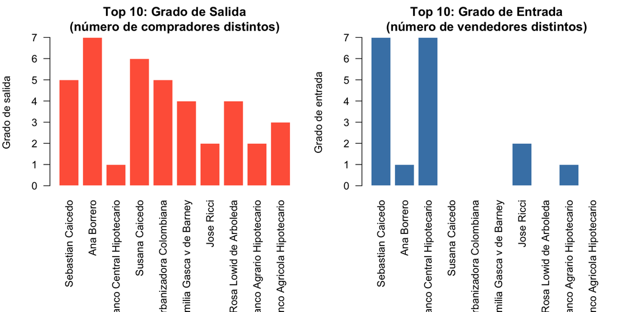

```r
top10 <- head(tabla_grado, 10)

par(mfrow = c(1, 2), mar = c(10, 4, 3, 1))

barplot(top10$Vendió_a,
        names.arg = top10$Actor, las = 2,
        col = "tomato", border = "white",
        main = "Top 10: Grado de Salida\n(número de compradores distintos)",
        ylab = "Grado de salida")

barplot(top10$Compró_a,
        names.arg = top10$Actor, las = 2,
        col = "steelblue", border = "white",
        main = "Top 10: Grado de Entrada\n(número de vendedores distintos)",
        ylab = "Grado de entrada")
```

```r
par(mfrow = c(1, 1))
```

## 7.2 Distribución de grado

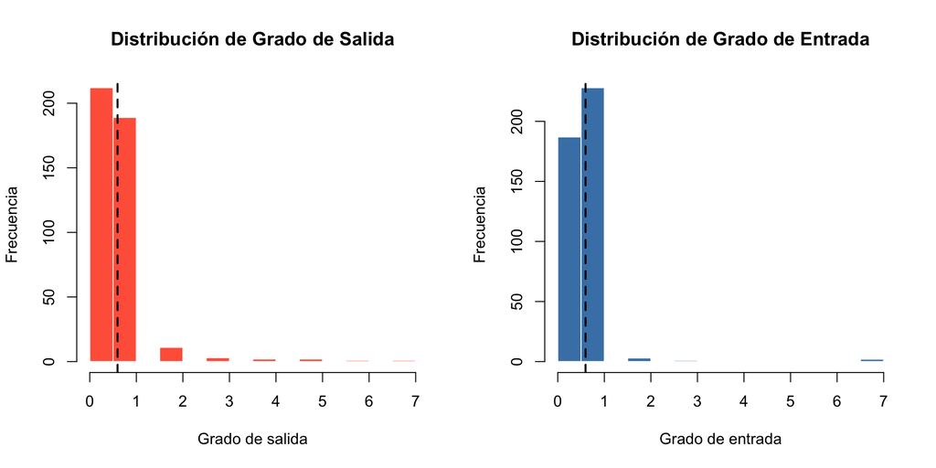

```r
par(mfrow = c(1, 2))

hist(grado_out,
     col = "tomato", border = "white", breaks = 20,
     main = "Distribución de Grado de Salida",
     xlab = "Grado de salida", ylab = "Frecuencia")
abline(v = mean(grado_out), col = "black", lwd = 2, lty = 2)

hist(grado_in,
     col = "steelblue", border = "white", breaks = 20,
     main = "Distribución de Grado de Entrada",
     xlab = "Grado de entrada", ylab = "Frecuencia")
abline(v = mean(grado_in), col = "black", lwd = 2, lty = 2)
```

```r
par(mfrow = c(1, 1))
```

## 7.3 Centralidad de Intermediación (*Betweenness*)

¿Qué actores actúan como **puentes** en el mercado inmobiliario? Un broker con alta intermediación conecta vendedores con compradores que de otra forma no se encontrarían.

```r
betw <- betweenness(g, directed = TRUE, normalized = TRUE)

tabla_betw <- data.frame(
  Actor          = V(g)$name,
  Intermediación = round(betw, 4)
) %>%
  arrange(desc(Intermediación))

rownames(tabla_betw) <- NULL

cat("Top 20 actores por intermediación:\n")
```

```
## Top 20 actores por intermediación:
```

```r
head(tabla_betw, 20)
```

|  | Actor | Intermediación |
| --- | --- | --- |
| 1 | Sebastian Caicedo | 2e-04 |
| 2 | Abelardo Astudillo | 0e+00 |
| 3 | Abelardo Castillo | 0e+00 |
| 4 | Absalon Leon Diaz | 0e+00 |
| 5 | Adela Cruz | 0e+00 |
| 6 | Agustin Velazco B | 0e+00 |
| 7 | Aida Micaela Velasco Garcia | 0e+00 |
| 8 | Alejandro Caicedo | 0e+00 |
| 9 | Alfonso Garces Valencia | 0e+00 |
| 10 | Alfonso Martinez Velasco | 0e+00 |

[output cut: 10 more lines]

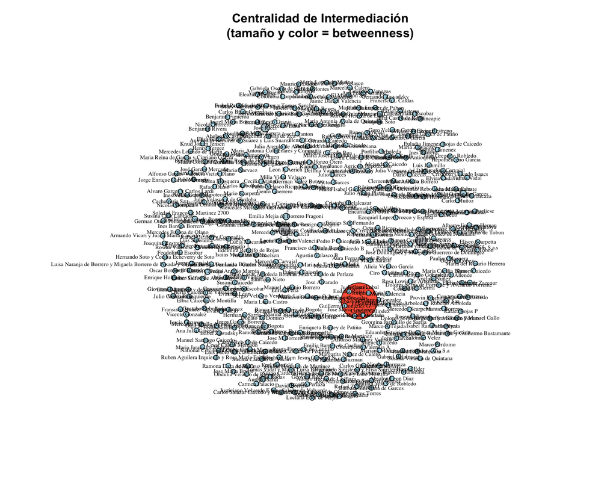

```r
set.seed(42)

# Escalar betweenness para el tamaño de los nodos
betw_norm <- (betw - min(betw)) / (max(betw) - min(betw))

plot(g,
     layout          = layout_with_fr(g),
     vertex.size     = betw_norm * 20 + 3,
     vertex.color    = colorRampPalette(c("lightblue", "tomato"))(100)[
                         ceiling(betw_norm * 99) + 1
                       ],
     vertex.label    = ifelse(betw >= quantile(betw, 0.90),
                              V(g)$name, NA),
     vertex.label.cex   = 0.55,
     vertex.label.color = "black",
     edge.width      = 0.5,
     edge.color      = adjustcolor("gray50", alpha.f = 0.4),
     edge.arrow.size = 0.2,
     main            = "Centralidad de Intermediación\n(tamaño y color = betweenness)"
)
```

## 7.4 Fuerza de nodo: volumen total transado

Además del grado, podemos medir el **volumen total** de pesos que fluye por cada actor (la suma de los valores de todas sus transacciones).

```r
# Fuerza de salida: total vendido
fuerza_out <- strength(g, mode = "out", weights = E(g)$peso)

# Fuerza de entrada: total comprado
fuerza_in  <- strength(g, mode = "in",  weights = E(g)$peso)

tabla_fuerza <- data.frame(
  Actor         = V(g)$name,
  Total_vendido = round(fuerza_out),
  Total_comprado = round(fuerza_in),
  Total_transado = round(fuerza_out + fuerza_in)
) %>%
  arrange(desc(Total_transado))

rownames(tabla_fuerza) <- NULL

cat("Top 20 actores por volumen total transado (en pesos):\n")
```

```
## Top 20 actores por volumen total transado (en pesos):
```

```r
head(tabla_fuerza, 20)
```

|  | Actor | Total_vendido | Total_comprado | Total_transado |
| --- | --- | --- | --- | --- |
| 1 | Banco Agrario Hipotecario | 134000 | 500 | 134500 |
| 2 | Jaime Gomez C | 0 | 130000 | 130000 |
| 3 | Silvio Cardena, Rosa de Cardenas y Carlos Navarro | 123000 | 0 | 123000 |
| 4 | Adolfo Bueno de La Plaza | 0 | 123000 | 123000 |
| 5 | Jorge Garces Borrero | 30000 | 80000 | 110000 |
| 6 | Gernando Zawadzky | 90000 | 0 | 90000 |
| 7 | Francisco L Caldas | 0 | 90000 | 90000 |
| 8 | Pedro Sanchez y Compañía | 80000 | 0 | 80000 |
| 9 | Rafael Rojas P | 65891 | 0 | 65891 |
| 10 | Jorge Steffen Glomm y Manuel Gallo | 0 | 65891 | 65891 |

[output cut: 10 more lines]

## 7.5 Tabla comparativa de centralidades

```r
# Construir tabla unificada para los 20 actores más activos
top_actores <- head(tabla_grado$Actor, 20)

tabla_cent <- data.frame(
  Actor          = top_actores,
  Grado_total    = (grado_out + grado_in)[top_actores],
  Grado_salida   = grado_out[top_actores],
  Grado_entrada  = grado_in[top_actores],
  Intermediación = round(betw[top_actores], 3),
  Vol_transado   = round((fuerza_out + fuerza_in)[top_actores])
)

rownames(tabla_cent) <- NULL

knitr::kable(tabla_cent,
             col.names = c("Actor", "Grado total", "Salida (vendió)",
                           "Entrada (compró)", "Intermediación", "Vol. transado ($)"),
             caption = "Centralidades — Red Inmobiliaria Cali (1938–1943)",
             format.args = list(big.mark = "."))
```

Centralidades — Red Inmobiliaria Cali (1938–1943)

| Actor | Grado total | Salida (vendió) | Entrada (compró) | Intermediación | Vol. transado ($) |
| --- | --- | --- | --- | --- | --- |
| Sebastian Caicedo | 12 | 5 | 7 | 0 | 8.850 |
| Ana Borrero | 8 | 7 | 1 | 0 | 3.680 |
| Banco Central Hipotecario | 8 | 1 | 7 | 0 | 48.950 |
| Susana Caicedo | 6 | 6 | 0 | 0 | 1.706 |
| Sociedad Urbanizadora Colombiana | 5 | 5 | 0 | 0 | 19.893 |
| Emilia Gasca v de Barney | 4 | 4 | 0 | 0 | 44.424 |
| Jose Ricci | 4 | 2 | 2 | 0 | 34.080 |
| Rosa Lowid de Arboleda | 4 | 4 | 0 | 0 | 590 |
| Banco Agrario Hipotecario | 3 | 2 | 1 | 0 | 134.500 |
| Banco Agricola Hipotecario | 3 | 3 | 0 | 0 | 11.200 |
| Banco de Bogota | 3 | 2 | 1 | 0 | 26.000 |
| Banco de Colombia | 3 | 1 | 2 | 0 | 31.012 |
| Edelmira Rengifo de Rojas | 3 | 3 | 0 | 0 | 7.763 |
| Guillermo Gonzalez | 3 | 3 | 0 | 0 | 1.500 |
| Nila Osorio de Garces | 3 | 2 | 1 | 0 | 5.645 |
| Ernesto Granja | 3 | 0 | 3 | 0 | 8.470 |
| Asuncion Lopez de Salazar | 2 | 1 | 1 | 0 | 2.800 |
| Aurelio Sardi | 2 | 1 | 1 | 0 | 2.200 |
| Banco Agricola | 2 | 2 | 0 | 0 | 2.656 |
| Banco Hipotecario de Bogota | 2 | 2 | 0 | 0 | 5.500 |

# 8 Detección de Comunidades

Para detectar comunidades en un grafo dirigido, convertimos temporalmente a no dirigido.

```r
set.seed(42)

# Convertir a no dirigido para la detección de comunidades
g_nodir <- as.undirected(g, mode = "collapse",
                          edge.attr.comb = list(peso = "sum", n_transac = "sum"))

# Algoritmo de Louvain
comunidades <- cluster_louvain(g_nodir, weights = E(g_nodir)$peso)

cat("Número de comunidades:", length(comunidades), "\n")
```

```
## Número de comunidades: 171
```

```r
cat("Modularidad          :", round(modularity(comunidades), 3), "\n")
```

```
## Modularidad          : 0.968
```

```r
# Composición de cada comunidad (solo las más grandes)
membresia <- membership(comunidades)
for (i in seq_along(comunidades)) {
  miembros <- V(g_nodir)$name[membresia == i]
  if (length(miembros) >= 3) {
    cat(sprintf("\nComunidad %d (%d actores): %s%s\n",
                i, length(miembros),
                paste(head(miembros, 8), collapse = ", "),
                if (length(miembros) > 8) ", ..." else ""))
  }
}
```

```
##
## Comunidad 7 (5 actores): Alejandro Caicedo, Banco Aleman Antioqueño, Banco de Colombia, Porfilio Arboleda, Carlos Sardi
##
## Comunidad 11 (3 actores): Alfredo Herrera M, Josefina Rincon de Borrero, Soledad Franco de Martinez 2700
##
## Comunidad 14 (9 actores): Ana Borrero, Emilia Mejia de Borrero Fragoni, Ignacio Sinisterra, Ana Garcia, Ester Narvaez, Leonor Marquez, Lucia Tejada de Valencia, Mercedes Villegas, ...
##
## Comunidad 18 (7 actores): Angel Maria Zapata, Ismael Zea, Jose Ricci, Mercedes Luna, Rufino Caicedo y Jovita de Caicedo, Angelina Zapata de Zea, Ernesto Granja
##
## Comunidad 23 (3 actores): Asuncion Lopez de Salazar, Maria Narvaez, Ester Mendimanuela
##
## Comunidad 26 (3 actores): Aurelio Sardi, Jaime Rodas, Carmen Palacio
##
## Comunidad 27 (4 actores): Banco Agrario Hipotecario, Clemente Matta Otero, Jaime Gomez C, Joaquina Hurtado de Piedrahita
##
## Comunidad 28 (3 actores): Banco Agricola, Guillermo Caicedo Alban, Hernando Caicedo
##
## Comunidad 29 (4 actores): Banco Agricola Hipotecario, Delfina Vasquez del Castillo y Julia Vasquez del Duque, Elvira Concha de Calderon, Maria del Rosario
##
## Comunidad 30 (9 actores): Banco Central Hipotecario, Camilo Dominguez y Mercedes Sarasti, Cayetano Caidedo, Donato Domenico y Maria Velazco de Domenico, Jose Dominguez y Margarita Guerrero de Domingez, Julia Velasco v, Roberto Neumann y Monica Teresa Gomez de Neumann, Trifilo Martinez y Emilia Ho…
##
## Comunidad 31 (3 actores): Banco Hipotecario de Bogota, Marina Salazar de Castaño, Ricardo Bonilla Torres
##
## Comunidad 32 (4 actores): Banco de Bogota, Santiago Hoyos F, Donato Di Domico, Ramon Jaramillo
##
## Comunidad 37 (3 actores): Berta Caicedo de Velasquez, Elbia Caicedo de Montilla, Gustabo Rebolledo
##
## Comunidad 39 (3 actores): Camara de Comercio Barranquilla, Jose M Borrero, Juan de Dios Borrero
##
## Comunidad 40 (4 actores): Carlos Muñoz, Nila Osorio de Garces, Ana Maria Faraste, Marina Belarcaza
##
## Comunidad 43 (3 actores): Cecilia Arango, Pablo Velasco, Genlo Guerrero
##
## Comunidad 47 (3 actores): Cristobal Belalcazar, Luis Ramos, Francisca Monsalve
##
## Comunidad 54 (4 actores): Edelmira Rengifo de Rojas, Arnoldo Michaelsen, Isaias Montezuma Paz, Lucia Macarane
##
## Comunidad 64 (5 actores): Emilia Gasca v de Barney, Emilia Barney de Cuellar, Emilia Barney de Martinez, Enriqueta Barney de Patiño, Maria Ines Barney
##
## Comunidad 70 (15 actores): Euladia Rojas, Gabriel Galindez, Guillermo Gonzales, Guillermo Gonzalez, Jorgino Cabal, Jose Maria Guiterrez, Juan Castillo, Sebastian Caicedo, ...
```

[output cut: 11 more lines]

```
## Comunidad 111 (3 actores): Juana Mosquera, Victor Olano, Rafael Olano
##
## Comunidad 116 (3 actores): Leon E Aerich, David Aerich, Milia Vidal Velasco
##
## Comunidad 125 (3 actores): Margarita Garces, Ruth Santander de Pabon, Joaquina Soto
##
## Comunidad 135 (3 actores): Mario Scarpetta, Carlos Rebolledo, Pablo Castro
##
## Comunidad 152 (3 actores): Ricardo Arboleda, German Velez Botero, Roberto Muñeton
##
## Comunidad 154 (5 actores): Rosa Lowid de Arboleda, Carlos Antonio Gonzalez, Central B, Efrain Rivas, Esequiel Sierrra
##
## Comunidad 162 (6 actores): Sociedad Urbanizadora Colombiana, Alfonso Caicedo Roa, Gerardo Caicedo, Maria Josefa Giraldo de Garces, Mario de Caicedo, Ruben Orozco
##
## Comunidad 165 (7 actores): Susana Caicedo, Evaristo Leon, Geronimo Ledezma, Gregorio Escobar, Julio Perez, Medardo Vallejo, Pedro Antinio Marpia
```

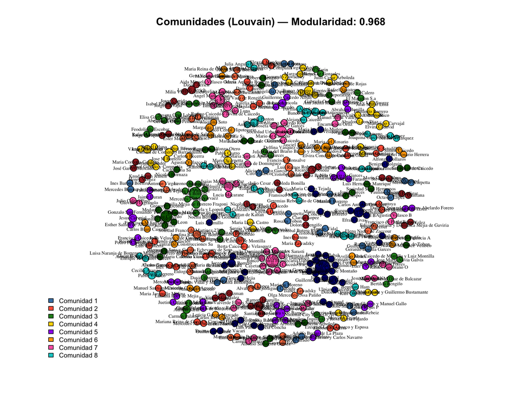

```r
set.seed(42)

# Paleta de colores para comunidades
paleta <- c("steelblue", "tomato", "forestgreen", "gold",
            "purple", "orange", "hotpink", "cyan3",
            "brown", "darkgreen", "navy", "coral")

n_com <- length(comunidades)
colores_com <- paleta[membresia %% length(paleta) + 1]

grado_nd <- degree(g_nodir)

plot(g_nodir,
     layout          = layout_with_fr(g_nodir),
     vertex.size     = sqrt(grado_nd) * 2.5 + 2,
     vertex.color    = colores_com,
     vertex.label    = ifelse(grado_nd >= quantile(grado_nd, 0.85),
                              V(g_nodir)$name, NA),
     vertex.label.cex   = 0.55,
     vertex.label.color = "black",
     edge.width      = 0.5,
     edge.color      = adjustcolor("gray60", alpha.f = 0.4),
     main            = paste0("Comunidades (Louvain) — Modularidad: ",
                              round(modularity(comunidades), 3))
)

legend("bottomleft",
       legend = paste("Comunidad", 1:min(n_com, 8)),
       fill   = paleta[1:min(n_com, 8)],
       cex    = 0.75,
       bty    = "n")
```

# 9 Evolución Temporal

¿Cómo cambia la red año a año?

```r
años <- sort(unique(datos$fecha))

stats_año <- lapply(años, function(a) {
  aristas_a <- datos %>%
    filter(fecha == a, !is.na(Valor)) %>%
    select(from = vendedor, to = comprador, peso = Valor)

  if (nrow(aristas_a) == 0) return(NULL)

  g_a <- graph_from_data_frame(aristas_a, directed = TRUE)

  data.frame(
    Año        = a,
    Nodos      = vcount(g_a),
    Aristas    = ecount(g_a),
    Vol_total  = round(sum(aristas_a$peso)),
    Densidad   = round(edge_density(g_a), 4)
  )
}) %>%
  bind_rows()

knitr::kable(stats_año,
             col.names = c("Año", "Actores", "Transacciones",
                           "Volumen total ($)", "Densidad"),
             caption = "Estadísticas de la red por año",
             format.args = list(big.mark = "."))
```

Estadísticas de la red por año

| Año | Actores | Transacciones | Volumen total ($) | Densidad |
| --- | --- | --- | --- | --- |
| 1.938 | 70 | 39 | 495.135 | 0.0081 |
| 1.939 | 125 | 71 | 442.177 | 0.0046 |
| 1.940 | 97 | 62 | 187.527 | 0.0067 |
| 1.941 | 31 | 16 | 34.363 | 0.0172 |
| 1.943 | 117 | 66 | 463.862 | 0.0049 |

# 10 Exportación

## 10.1 Exportar a Gephi

```r
# Exportar el grafo completo en formato GraphML para Gephi
write_graph(g, "red_notaria2.graphml", format = "graphml")
cat("Exportado: red_notaria2.graphml\n")
cat("Abrir en Gephi: File > Open > red_notaria2.graphml\n")
```

## 10.2 Exportar tablas de centralidad

```r
# Guardar tabla de centralidades como CSV
write.csv(tabla_cent, "centralidades_notaria2.csv", row.names = FALSE)
cat("Exportado: centralidades_notaria2.csv\n")
```

*Documento preparado para el curso Introducción a la Complejidad 2026-I, Universidad del Valle.*